# IODS course project

# For the variables I will be using for my analysis I will choose the following four: sex, age, activities and freetime. My personal hypothesis is that males will consume more alcohol than females, age increasing correlates with the increase in alcohol consumption in this population and then I am unsure about activites. I don’t really have a guess as to how it will effect alcohol consumption or be related to it. I also think that alcohol consumption might increase with freetime.

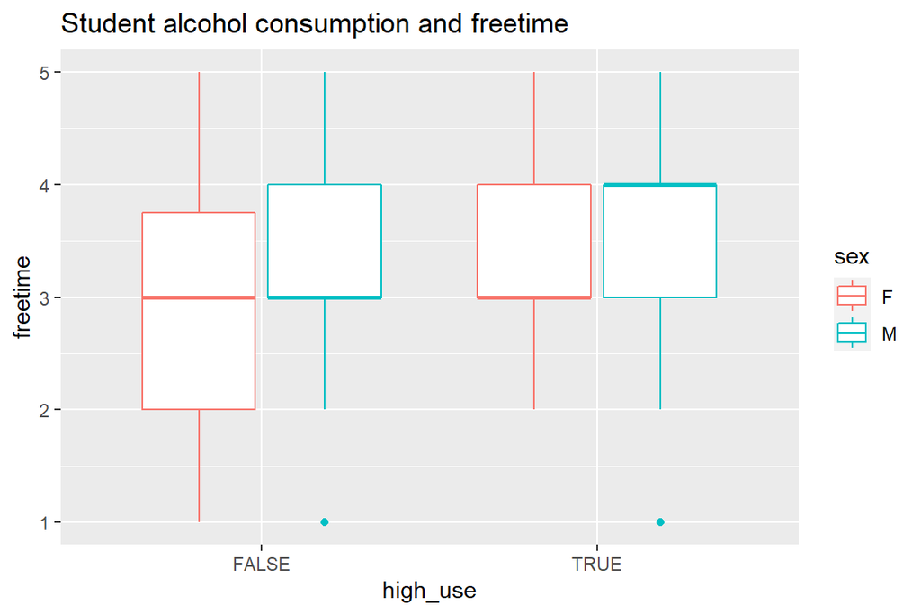

```r
g1 <- ggplot(alc, aes(x = high_use, y = freetime, col = sex))
g1 + geom_boxplot() + ylab("freetime") + ggtitle("Student alcohol consumption and freetime")
```

```r
alc %>% group_by(activities, high_use) %>% summarise(count = n())
```

```
## # A tibble: 4 x 3
## # Groups:   activities [2]
##   activities high_use count
##   <chr>      <lgl>    <int>
## 1 no         FALSE      120
## 2 no         TRUE        59
## 3 yes        FALSE      139
## 4 yes        TRUE        52
```

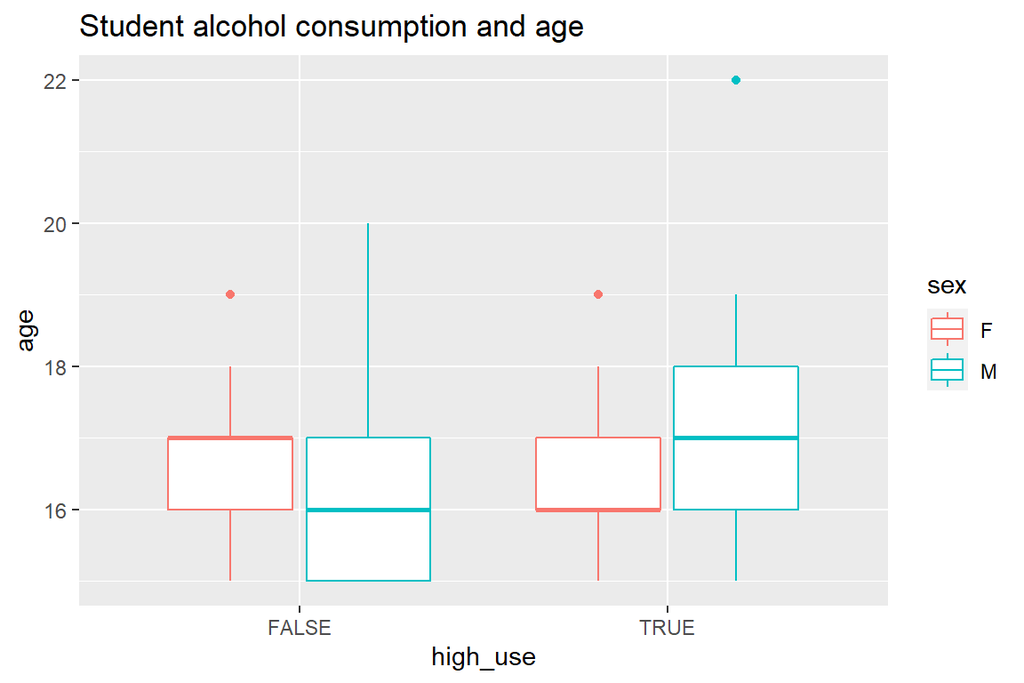

```r
g3 <- ggplot(alc, aes(x = high_use, y = age, col = sex))
g3 + geom_boxplot() + ggtitle("Student alcohol consumption and age") + ylab("age")
```

# The first boxplot is student alcohol consumption and freetime. There seems to be a an outlier in high use with low freetime and likewise in low use with low freetime. According to this there might be a relationship with alcohol consumption and freetime atleast for females, but there seems to be no significant difference for males.

#Then we have a cross tabulation of activities and high alcohol consumption. We can see that there were sligthly more people with higher alcohol consumption among people with no activites and the percentage of people with high alcohol consumption in people with no activites was also higher. Therefore, there might be a statistical relationship between having activites and alcohol consumption.

#The third graph is also a boxplot this time with student alcohol consumption and age. There are outliers in people with high alcohol consumption among males and females. There is also an outlier in the low alcohol consumption group on the female side, but not on the male side. There seems to be a potential relationship between age and alcohol consumption based on this plot.

```r
m <- glm(high_use ~ freetime + activities + sex + age, data = alc, family = "binomial")
summary(m)
```

```
##
## Call:
## glm(formula = high_use ~ freetime + activities + sex + age, family = "binomial",
##     data = alc)
##
## Deviance Residuals:
##     Min       1Q   Median       3Q      Max
## -1.5085  -0.8457  -0.6611   1.1868   2.1484
##
## Coefficients:
##               Estimate Std. Error z value Pr(>|z|)
## (Intercept)   -5.30557    1.73720  -3.054 0.002257 **
## freetime       0.30441    0.12548   2.426 0.015268 *
## activitiesyes -0.40662    0.24002  -1.694 0.090241 .
## sexM           0.86104    0.24403   3.528 0.000418 ***
## age            0.19336    0.09988   1.936 0.052885 .
## ---
## Signif. codes:  0 '***' 0.001 '**' 0.01 '*' 0.05 '.' 0.1 ' ' 1
##
## (Dispersion parameter for binomial family taken to be 1)
##
##     Null deviance: 452.04  on 369  degrees of freedom
## Residual deviance: 423.40  on 365  degrees of freedom
## AIC: 433.4
##
## Number of Fisher Scoring iterations: 4
```

```r
coef(m)
```

```
##   (Intercept)      freetime activitiesyes          sexM           age
##    -5.3055743     0.3044065    -0.4066241     0.8610394     0.1933607
```

```r
OR <- coef(m) %>% exp
CI <- confint(m) %>% exp
cbind(OR, CI)
```

```
##                        OR        2.5 %    97.5 %
## (Intercept)   0.004963846 0.0001539286 0.1423453
## freetime      1.355820025 1.0633744995 1.7410289
## activitiesyes 0.665894423 0.4144476790 1.0636972
## sexM          2.365618184 1.4721433120 3.8386581
## age           1.213320375 0.9992506713 1.4797392
```

# Now I have fitted a logistic regression model with my selected variables freetime, activites, sex and age to explain high alchol consumption. We can then look at the odds ratios printed out to take a look at how each variable affects alcohol consumption. So out of the 4 variables I chose, 3 are positively linked to high alcohol consumption. Freetime and age seem to behave as similarly effective predictors of alcohol consumption, but as I theorised sex was by far the biggest factor. Activites seemed to affect alcohol consumption negatively, which I did not make a prediction for. However intuitively and very non-statistic point of view if you have nothing to do, why not have a drink? The outliers we saw in our boxplot investigation appear here again, since for example the age variable’s 2.5% confidence interval drops to an odd’s ratio of below one, even though base odds ratio number would indicate it as being a predictor of alcohol consumption. The confidence intervals also appear to hint that in some cases an increase in activites could lead to an increase in alcohol consumption, but other than these two cases they provide no further revelations.

```r
probabilities <- predict(m, type = "response")
alc <- mutate(alc, probability = probabilities)
alc <- mutate(alc, prediction = probability > 0.5)
select(alc, age, freetime, sex, high_use, activities, probability, prediction) %>% tail(10)
```

```
##     age freetime sex high_use activities probability prediction
## 361  17        4   M    FALSE        yes   0.4142554      FALSE
## 362  19        3   M    FALSE         no   0.5355743       TRUE
## 363  18        4   M     TRUE         no   0.5630584       TRUE
## 364  18        3   F    FALSE         no   0.2866189      FALSE
## 365  18        4   F    FALSE        yes   0.2661822      FALSE
## 366  19        4   F    FALSE        yes   0.3056110      FALSE
## 367  18        3   F    FALSE         no   0.2866189      FALSE
## 368  18        1   F    FALSE        yes   0.1270498      FALSE
## 369  17        4   M     TRUE         no   0.5150512       TRUE
## 370  18        4   M     TRUE         no   0.5630584       TRUE
```

```r
table(high_use = alc$high_use, prediction = alc$prediction)
```

```
##         prediction
## high_use FALSE TRUE
##    FALSE   251    8
##    TRUE     94   17
```

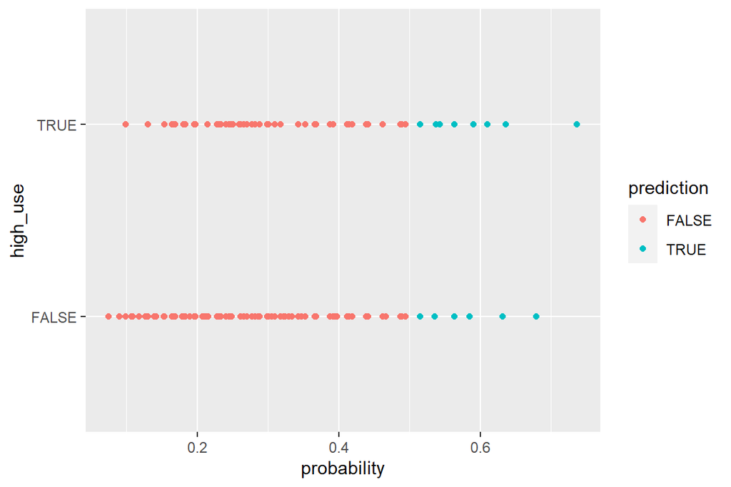

```r
g4 <- ggplot(alc, aes(x = probability, y = high_use, col = prediction))
g4 + geom_point()
```

```r
table(high_use = alc$high_use, prediction = alc$prediction) %>% prop.table() %>% addmargins()
```

```
##         prediction
## high_use      FALSE       TRUE        Sum
##    FALSE 0.67837838 0.02162162 0.70000000
##    TRUE  0.25405405 0.04594595 0.30000000
##    Sum   0.93243243 0.06756757 1.00000000
```

```r
loss_func <- function(class, prob) {
  n_wrong <- abs(class - prob) > 0.5
  mean(n_wrong)
}

loss_func(class = alc$high_use, prob = 0)
```

```
## [1] 0.3
```